# PracaDom12_MBogdańska

Magdalena Bogdańska

Modele liniowe i mieszane

## Task

Verify whether there is any relation between variables “thick” and “soil” in dataset “toy”.

Try two models: simple linear regression model with just one dependent variable and a model which takes into account spatial structure of measurements (variables east and north).

Compare these two models and answer the question: is there a significant relation between variables thick (y) and soil (dependent variable)?

Data to be considered is of a following form:

```r
head(spdata)
```

```
##   X east north thick     soil dummy
## 1 1  0.7  59.6  34.1 3.635764     1
## 2 2  2.1  82.7  42.2 3.502083     1
## 3 3  4.7  75.1  39.5 3.946545     1
## 4 4  4.8  52.8  34.3 2.941715     1
## 5 5  5.9  67.1  37.0 3.866264     1
## 6 6  6.0  35.7  35.9 3.018548     1
```

It contains the thickness and qualities of coal seams measured at different coordinates.

## Model1

What is the relation between thickness and quality of soil without taking into account any spatial variable? Let us see it graphically.

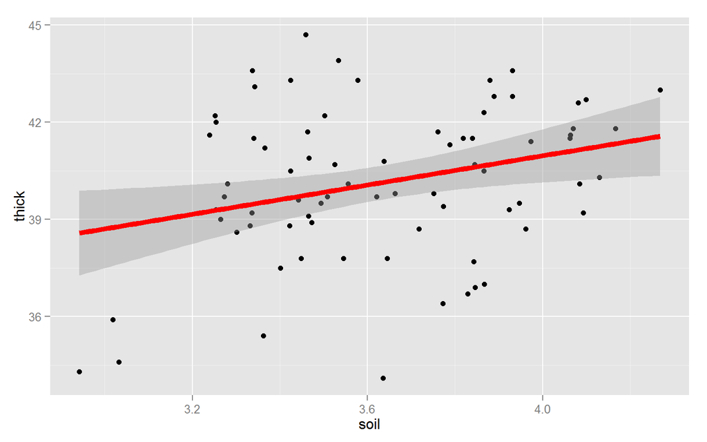

```r
ggplot(spdata, aes(soil,thick)) +
  geom_point() +
  stat_smooth(method="lm")+
  geom_smooth(se=FALSE, color="red", size=2,method="lm")
```

I verify first linear regression model: thick~soil.

```r
model1 <- lm(thick~ soil, data=spdata)
summary(model1)
```

```
##
## Call:
## lm(formula = thick ~ soil, data = spdata)
##
## Residuals:
##     Min      1Q  Median      3Q     Max
## -6.0414 -1.1975  0.0876  1.4836  4.9584
##
## Coefficients:
##             Estimate Std. Error t value Pr(>|t|)
## (Intercept)  31.9420     3.1570  10.118 1.54e-15 ***
## soil          2.2552     0.8656   2.605   0.0111 *
## ---
## Signif. codes:  0 '***' 0.001 '**' 0.01 '*' 0.05 '.' 0.1 ' ' 1
##
## Residual standard error: 2.278 on 73 degrees of freedom
## Multiple R-squared:  0.08508,    Adjusted R-squared:  0.07254
## F-statistic: 6.788 on 1 and 73 DF,  p-value: 0.01111
```

Variable soil is significant in linear regression model.

However the relation between two variables considered doesn’t seem to be purely linear.

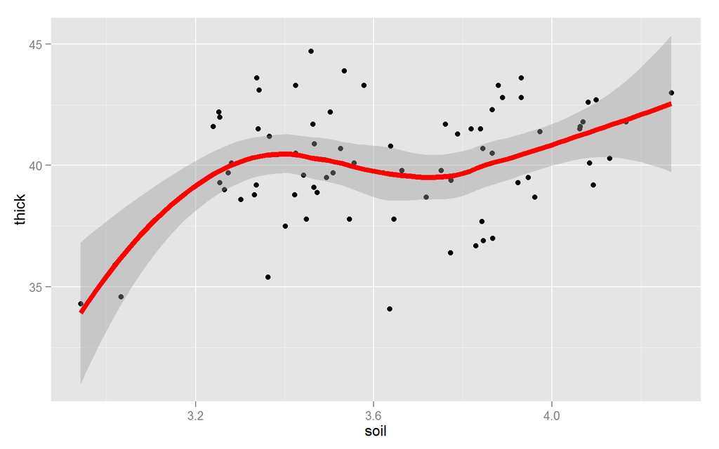

```r
ggplot(spdata, aes(soil,thick)) +
  geom_point() +
  stat_smooth(method="loess")+
  geom_smooth(se=FALSE, color="red", size=2,method="loess")
```

## Model2

Let us see graphically whether there is any dependence of thickness on the geographical location. I will plot the variogram.

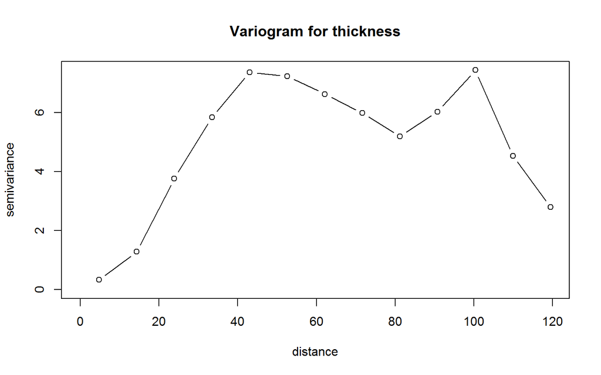

```r
v1 <- variog(coords = spdata[,2:3], data = spdata$thick, message=FALSE)
plot(v1, type = "b", main = "Variogram for thickness")
```

From the variogram one can clearly see that there is relation between thickness of soil and distance. Thus in the subsequent model I will take into account the spatial structure of measurements (variables east and north, describing latitude and longitude). There are several different forms that the spatial autocorrelation can take, here I will consider exponential, Gaussian, spherical and linear forms. I will compare model without spatial components with model with different spatial autocorrelation structures.

```r
model0 <- lme(thick ~ 1, data = spdata, random = ~ 1 | dummy)

modelExp <- update(model0, correlation = corExp(1, form = ~ east + north), method = "ML")

modelGaus<- update(model0, correlation = corGaus(1, form = ~ east + north), method = "ML")

modelSpher <- update(model0, correlation = corSpher(1, form = ~ east + north), method = "ML")

modelLin <- update(model0, correlation = corLin(1, form = ~ east + north), method = "ML")

c(AIC(model0), AIC(modelExp), AIC(modelGaus), AIC(modelSpher), AIC(modelLin))
```

```
## [1] 347.75115 167.12094  89.55566 147.89675 165.48804
```

Based on the Akaike inforation criterion I choose Gaussian correlation structure.

I will now compare model with and without spatial structure considering also variable soil as fixed variable.

```r
modelGausFinal <- lme(thick ~ soil, data=spdata, correlation = corGaus(form = ~ east + north), random= ~1|dummy, method="ML")
summary(modelGausFinal)
```

```
## Linear mixed-effects model fit by maximum likelihood
##  Data: spdata
##        AIC      BIC    logLik
##   91.50733 103.0948 -40.75366
##
## Random effects:
##  Formula: ~1 | dummy
##          (Intercept) Residual
## StdDev: 7.497427e-05 2.088388
##
## Correlation Structure: Gaussian spatial correlation
##  Formula: ~east + north | dummy
##  Parameter estimate(s):
##    range
## 20.43726
## Fixed effects: thick ~ soil
##                Value Std.Error DF  t-value p-value
## (Intercept) 40.32797 0.5877698 73 68.61184  0.0000
## soil         0.00348 0.0160363 73  0.21693  0.8289
##  Correlation:
##      (Intr)
## soil -0.102
##
## Standardized Within-Group Residuals:
##        Min         Q1        Med         Q3        Max
## -2.9882458 -0.7133759 -0.1146242  0.6745680  2.0877341
##
## Number of Observations: 75
## Number of Groups: 1
```

Now in the model with Gaussian spatial structure variable soil isn’t statistically significant as p-value is big.

## Conclusions

Without including the spatial structure in the model, quality of soil is a statistically significant predictor of thickness. After adding the spatial structure, this relationship becomes not significant.